# Mapping Example

Jeekin Lau

Updated: 11/30/2022

# Introduction

This is a tutorial using a very clean dataset from array generated data on a well characterized autotetraploid garden rose mapping population that has been published already [Rose Rosette Disease Resistance Loci Detected in Two Interconnected Tetraploid Garden Rose Populations](https://www.frontiersin.org/articles/10.3389/fpls.2022.916231/full)

To download the dataset please go to: https://github.com/jeekinlau/mapping_example/tree/main/data

Tutorial link:

https://jeekinlau.github.io/mapping_example/tutorial/Mapping_Example.html

# Import the data

Download the dataset and import the dataset into R. The data is organized in a way that mappoly recognizes it. must be in this format if you want to use `mappoly::read_geno_csv()` to read in your data. If you have a vcf file you can also use `mappoly::read_vcf()`

```r
setwd("~/GitHub/mapping_example/tutorial")
library(mappoly)
dat = read_geno_csv(file="../data/BExMG_subset.csv", ploidy = 4)
```

```
## Reading the following data:
##     Ploidy level: 4
##     No. individuals:  161
##     No. markers:  1382
##     No. informative markers:  1382 (100%)
##     ...
##     Done with reading.
##     Filtering non-conforming markers.
##     ...
##     Done with filtering.
```

Just a demonstration of using a vcf as input

```r
dat_vcf = read_vcf("../data/sweetpotato_chr1.vcf.gz", parent.1 = "PARENT1", parent.2 = "PARENT2",ploidy = 6)
```

# Filtering Data

## Filter by missing data

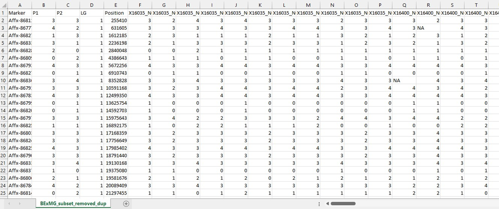

CSV input file

Typically, there will be many markers filtered out when filtered by marker, or by individual. Because this is a very well curated dataset, There are no markers filtered out. Start with 0.05 or 0.10 but there are no “rules” for what level to use.

```r
## Filtering dataset by marker
dat = filter_missing(input.data = dat, type = "marker",
                      filter.thres = 0.10, inter = F)

## Filtering dataset by individual
dat = filter_missing(input.data = dat, type = "individual",
                      filter.thres = 0.10, inter = F)
dat
```

```
## This is an object of class 'mappoly.data'
##     Ploidy level:                            4
##     No. individuals:                         161
##     No. markers:                             1382
##     Missing data:                            1.3%
##
##     This dataset contains chromosome information.
##     ----------
##     No. of markers per dosage combination in both parents:
##     P1 P2 freq
##      0  1  108
##      0  2   30
##      0  3    9
##      1  0  108
##      1  1  120
##      1  2   91
##      1  3   42
##      1  4   10
##      2  0   32
##      2  1   75
##      2  2   97
##      2  3   60
##      2  4   29
##      3  0    7
##      3  1   40
##      3  2   77
##      3  3  167
##      3  4  116
##      4  1   10
##      4  2   36
##      4  3  118
```

## Filter by segregation distortion

Also very few markers removed due to good dataset. The figure below shows the marker types, the dosage of all the marker types, and the segregation distortion of the markers. Here also we apply an alpha=0.05 with Bonfferoni correction.

```r
## Filter according to segregation test
pval.bonf = 0.05/dat$n.mrk
mrks.chi.filt = filter_segregation(dat, chisq.pval.thres =  pval.bonf, inter = F)
seq.init = make_seq_mappoly(mrks.chi.filt)
seq.init
```

```
## This is an object of class 'mappoly.sequence'
##     ------------------------
##     Parameters not estimated
##     ------------------------
##     Ploidy level:       4
##     No. individuals:    161
##     No. markers:        1369
##
##     ----------
##     No. markers per sequence:
##     chrom No.mrk
##         1    166
##         2    281
##         3    163
##         4    189
##         5    150
##         6    217
##         7    203
##
##     ----------
##     No. of markers per dosage in both parents:
##    dP1 dP2 freq
##      0   1  107
##      0   2   29
##      0   3    8
##      1   0  107
##      1   1  120
##      1   2   90
##      1   3   42
##      1   4   10
##      2   0   31
##      2   1   75
##      2   2   97
##      2   3   60
##      2   4   29
##      3   0    7
##      3   1   40
##      3   2   77
##      3   3  164
##      3   4  116
##      4   1    8
##      4   2   35
##      4   3  117
```

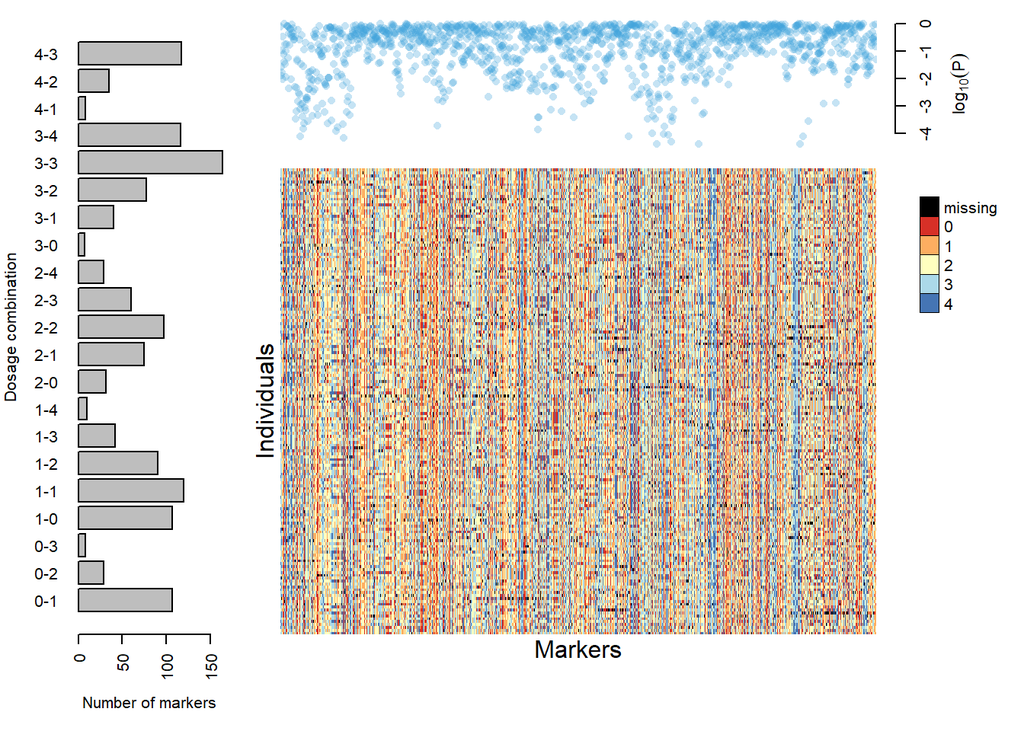

```r
plot(seq.init)
```

# Calculating recombination fractions

This step allows for the pairwise recombination fraction calculation between all markers. If you computer has multiple cores use the `parallel::detectCores()` function to find out how many cores your local computer has. This step takes a while especially with a laptop with limited cores and RAM memory. (**there are tricks around this email me for alternative strategies around this**)

```r
## Accounting for recombination fractions

all.rf.pairwise = est_pairwise_rf(input.seq = seq.init, ncpus = 6)
```

```
## INFO: Using  6  CPUs for calculation.
## INFO: Done with 936396  pairs of markers
## INFO: Calculation took: 106.61 seconds
```

## Plotting RF matrix

Plotting the RF matrix shows a heat map of markers that are closely linked versus those that are far away. Naturally we see that those markers group into the 7 chromosomes of the Rose genome.

```r
mat = rf_list_to_matrix(all.rf.pairwise)
```

```
## INFO: Going singlemode. Using one CPU.
```

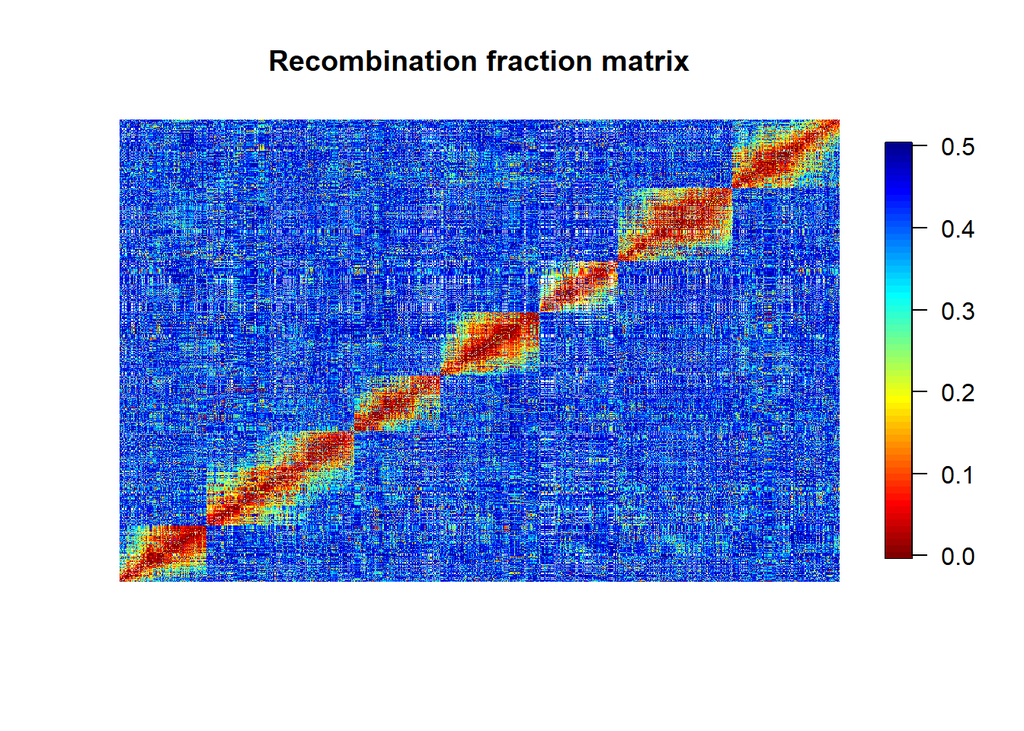

```r
plot(mat)
```

# Grouping

Next step is to group the markers into a list containing the necessary objects needed for mapping (ie markers and their two point rf estimate and a sequence of markers). There are several ways to approach this. Below we compare the grouping using UPGMA method, genomic (physical position according to genome position), and an intersect between the two.

```r
## Getting group information (UPGMA)
grs = group_mappoly(input.mat = mat,
                     expected.groups = 7,
                     comp.mat = TRUE,
                     inter = F)
grs
```

```
##   This is an object of class 'mappoly.group'
##   ------------------------------------------
##   Criteria used to assign markers to groups:
##
##     - Number of markers:          1369
##     - Number of linkage groups:   7
##     - Number of markers per linkage groups:
##     group n.mrk
##         1   170
##         2   220
##         3   152
##         4   283
##         5   197
##         6   159
##         7   188
##   ------------------------------------------
##     1   6   5   2   7   3   4 NoChr
## 1 164   0   0   0   0   6   0     0
## 2   1 216   0   2   1   0   0     0
## 3   1   0 150   1   0   0   0     0
## 4   0   1   0 276   3   2   1     0
## 5   0   0   0   2 195   0   0     0
## 6   0   0   0   0   4 155   0     0
## 7   0   0   0   0   0   0 188     0
##   ------------------------------------------
```

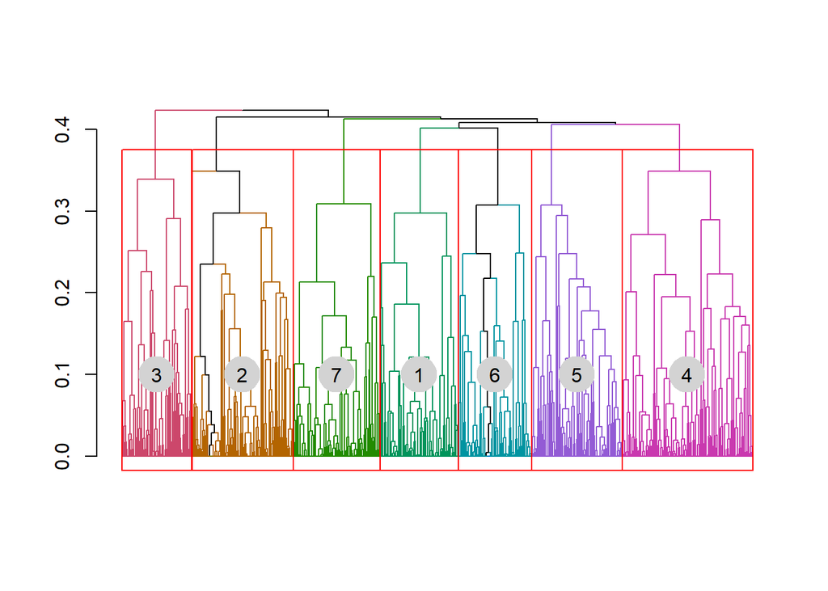

```r
plot(grs)
```

```r
## Making groups with intersection between UPGMA (rf) + genomic information (discards scaffolds)

LGS.inter=vector("list", 7)
for(j in 1:7){
  temp1 = make_seq_mappoly(grs, j, genomic.info=1)
  tpt = make_pairs_mappoly(all.rf.pairwise, input.seq = temp1)
  temp2 = rf_snp_filter(input.twopt = tpt, diagnostic.plot = FALSE)
  tpt2 = make_pairs_mappoly(tpt, input.seq = temp2)
  LGS.inter[[as.numeric(names(table(temp2$chrom))[which.max(table(temp2$chrom))])]] = list(seq = temp2, tpt = tpt2)
}


## Making groups only with genomic information (tends to bring more markers, but also discards scaffolds)
LGS.genomic = vector("list", 7)
for (i in 1:7){
  tempseq1 = make_seq_mappoly(dat, arg = paste0("seq",i), genomic.info = 1)
  mrks = intersect(tempseq1$seq.mrk.names, seq.init$seq.mrk.names)
  tempseq = make_seq_mappoly(dat, arg = mrks)
  temptpt = make_pairs_mappoly(all.rf.pairwise, input.seq = tempseq)
  rffilt = rf_snp_filter(input.twopt = temptpt, diagnostic.plot = FALSE)
  temptpt2 = make_pairs_mappoly(temptpt, input.seq = rffilt)
  LGS.genomic[[as.numeric(unique(rffilt$chrom))]] = list(seq = rffilt, tpt = temptpt2)
}


## Making groups with UPGMA (rf) information (includes scaffolds)
LGS.upgma=vector("list", 7)
for(j in 1:7){
  temp1 = make_seq_mappoly(grs, j)
  tpt = make_pairs_mappoly(all.rf.pairwise, input.seq = temp1)
  temp2 = rf_snp_filter(input.twopt = tpt, diagnostic.plot = FALSE)
  tpt2 = make_pairs_mappoly(tpt, input.seq = temp2)
  LGS.upgma[[as.numeric(names(table(temp2$chrom))[which.max(table(temp2$chrom))])]] = list(seq = temp2, tpt = tpt2)
}


## Comparing number of markers in each group
comp = data.frame(UPGMA_Genomic = unlist(lapply(LGS.inter, function(x) length(x$seq$seq.num))),
                  Genomic = unlist(lapply(LGS.genomic, function(x) length(x$seq$seq.num))),
                  UPGMA = unlist(lapply(LGS.upgma, function(x) length(x$seq$seq.num))))
comp
```

```
##   UPGMA_Genomic Genomic UPGMA
## 1           155     157   161
## 2           264     269   269
## 3           148     156   151
## 4           180     181   180
## 5           144     144   144
## 6           205     206   211
## 7           187     192   187
```

```r
LGS<-LGS.inter
```

# HMM chain

The HMM chain is used to order the markers. Below is a example of just ordering one chromosome. Later we will show how to parallelize this task by chromosome. (NOTE the map is only running quickly here because of the small number of markers and the good quality of the data)

```r
single_chrom <- est_rf_hmm_sequential(input.seq = LGS[[1]]$seq,
                               start.set = 3,
                               thres.twopt = 10,
                               thres.hmm = 50,
                               extend.tail = 30,
                               twopt = LGS[[1]]$tpt,
                               verbose = TRUE,
                               phase.number.limit = 20,
                               sub.map.size.diff.limit = 5)
```

```
## Number of markers: 155
```

```
## ════════════════════════════════════════════════════════════════════════════════ Initial sequence ══
```

```
## 3 markers...
## •    Trying sequence: 1 2 3 :
##        1 phase(s): .
```

```
## ══════════════════════════════════════════════════════════════════════ Done with initial sequence ══
```

```
## Making 'reestimate.single.ph.configuration = TRUE' to use map expansion
```

```
## 4  /4  :(2.6%)   9  : 1 ph     (1/1)       -- tail: 3   •••| ••••
## 5  /5  :(3.2%)   10 : 2 ph     (1/2)       -- tail: 4   •••| ••|•       ••|• ••|•
## 6  /6  :(3.9%)   11 : 1 ph     (1/1)       -- tail: 5   •••• ••|•
## 7  /7  :(4.5%)   14 : 9 ph     (1/9)       -- tail: 6   •••| •••|  ...  •••| ••|•
## 8  /8  :(5.2%)   16 : 1 ph     (1/1)       -- tail: 7   •••| ••|•
## 9  /9  :(5.8%)   17 : 1 ph     (1/1)       -- tail: 8   •••| ••|•
## 10 /10 :(6.5%)   18 : 1 ph     (1/1)       -- tail: 9   •••• ••|•
## 11 /11 :(7.1%)   19 : 1 ph     (1/1)       -- tail: 10  •••| ••|•
## 12 /12 :(7.7%)   20 : 1 ph     (1/1)       -- tail: 11  •••| ••••
## 13: not included (*linkage phases*)
## 13 /14 :(9%)     23 : 2 ph     (1/2)       -- tail: 12  •••• •|•|       •••• |••|
## 14 /15 :(9.7%)   24 : 1 ph     (1/1)       -- tail: 13  |||| •||•
## 15 /16 :(10.3%)  25 : 2 ph     (1/2)       -- tail: 14  •••• •••|       •••• |•••
## 16 /17 :(11%)    26 : 1 ph     (1/1)       -- tail: 15  •••• •||•
## 17 /18 :(11.6%)  27 : 1 ph     (1/1)       -- tail: 16  •••| ••••
## 18 /19 :(12.3%)  28 : 16 ph    (1/16)      -- tail: 17  •||| •|||  ...  •||| |•||
## 19 /20 :(12.9%)  29 : 1 ph     (1/1)       -- tail: 18  |||| |••|
## 20 /21 :(13.5%)  30 : 1 ph     (1/1)       -- tail: 19  |||• ||•|
## 21 /22 :(14.2%)  31 : 1 ph     (1/1)       -- tail: 20  •••| ••••
## 22 /23 :(14.8%)  32 : 1 ph     (1/1)       -- tail: 21  •••| ••••
## 23 /24 :(15.5%)  33 : 1 ph     (1/1)       -- tail: 22  |||• ||||
## 24 /25 :(16.1%)  34 : 3 ph     (1/3)       -- tail: 23  ||•| ••||  ...  ||•| •|•|
## 25 /26 :(16.8%)  35 : 1 ph     (1/1)       -- tail: 24  •••| •••|
## 26 /27 :(17.4%)  36 : 1 ph     (1/1)       -- tail: 25  •••• •••|
## 27 /28 :(18.1%)  37 : 3 ph     (1/3)       -- tail: 26  ••|| ||||  ...  •|•| ||||
## 28 /29 :(18.7%)  38 : 1 ph     (1/1)       -- tail: 27  •••• •••|
## 29 /30 :(19.4%)  39 : 1 ph     (1/1)       -- tail: 28  |||| ||•|
## 30 /31 :(20%)    40 : 1 ph     (1/1)       -- tail: 29  •••• ••|•
## 31 /32 :(20.6%)  41 : 1 ph     (1/1)       -- tail: 30  •••| •••|
## 32 /33 :(21.3%)  43 : 1 ph     (1/1)       -- tail: 30  |||• ||••
## 33 /34 :(21.9%)  44 : 4 ph     (1/4)       -- tail: 30  •••| ||||  ...  ••|• ||||
## 34 /35 :(22.6%)  45 : 2 ph     (1/2)       -- tail: 30  |•|| ||||       ||•| ||||
## 35 /36 :(23.2%)  46 : 1 ph     (1/1)       -- tail: 30  •|•• ||••
## 36 /37 :(23.9%)  47 : 1 ph     (1/1)       -- tail: 30  •••| ••||
## 37 /38 :(24.5%)  48 : 1 ph     (1/1)       -- tail: 30  ||•| ||||
## 38 /39 :(25.2%)  49 : 1 ph     (1/1)       -- tail: 30  •••| ••••
## 39 /40 :(25.8%)  50 : 1 ph     (1/1)       -- tail: 30  •••• •••|
## 40 /41 :(26.5%)  51 : 1 ph     (1/1)       -- tail: 30  |•|| ••••
## 41 /42 :(27.1%)  52 : 1 ph     (1/1)       -- tail: 30  •••• •••|
## 42 /43 :(27.7%)  53 : 1 ph     (1/1)       -- tail: 30  |•|| ||••
```

[output cut: 97 more lines]

```
## 140/141:(91%)    154: 1 ph     (1/1)       -- tail: 37  ••|| ||•|
## 141/142:(91.6%)  155: 1 ph     (1/1)       -- tail: 38  ••|| ||•|
## 142/143:(92.3%)  156: 2 ph     (1/2)       -- tail: 39  •||| ||•|       |•|| ||•|
## 143/144:(92.9%)  157: 1 ph     (1/1)       -- tail: 30  •••• ••|•
## 144/145:(93.5%)  158: 1 ph     (1/1)       -- tail: 30  |||| |•||
## 145/146:(94.2%)  159: 1 ph     (1/1)       -- tail: 30  •|•• ••|•
## 146/147:(94.8%)  160: 1 ph     (1/1)       -- tail: 30  ||•• ••|•
## 147/148:(95.5%)  162: 1 ph     (1/1)       -- tail: 30  ||•• ••|•
## 148/149:(96.1%)  163: 1 ph     (1/1)       -- tail: 30  ••|• ••••
## 149/150:(96.8%)  164: 1 ph     (1/1)       -- tail: 30  ||•• ••|•
## 150/151:(97.4%)  165: 1 ph     (1/1)       -- tail: 30  •••• •|••
## 151/152:(98.1%)  166: 1 ph     (1/1)       -- tail: 30  ||•• ••|•
## 152/153:(98.7%)  167: 1 ph     (1/1)       -- tail: 30  ||•• ••|•
## 153/154:(99.4%)  168: 2 ph     (1/2)       -- tail: 30  •••• •|•|       •••• ||••
## 154/155:(100%)   169: 1 ph     (1/1)       -- tail: 30  ||•• ••|•
```

```
## ══════════════════════════════════════════════════════ Reestimating final recombination fractions ══
```

```
## Markers in the initial sequence: 155
## Mapped markers                  : 154 (99.4%)
```

```
## ════════════════════════════════════════════════════════════════════════════════════════════════════
```

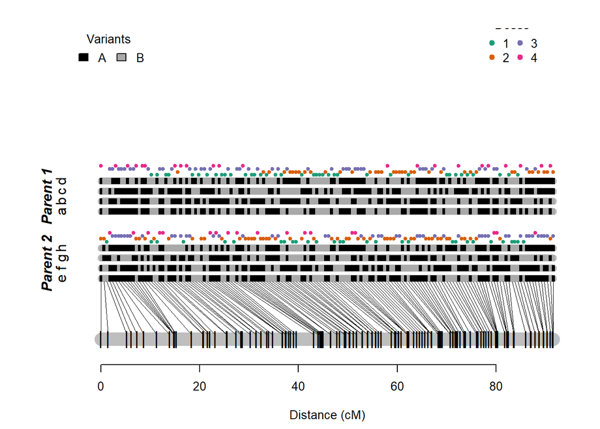

```r
plot(single_chrom)
```

## Parallel construction of all 7 LGs

```r
## Performing parallel computation of hidden markov
phasing_and_hmm_rf <- function(X){
  fl <- paste0("output_map_ch_", unique(X$seq$chrom), ".txt")
  sink(fl)
  map <- est_rf_hmm_sequential(input.seq = X$seq,
                               start.set = 3,
                               thres.twopt = 10,
                               thres.hmm = 50,
                               extend.tail = 30,
                               twopt = X$tpt,
                               verbose = TRUE,
                               phase.number.limit = 20,
                               sub.map.size.diff.limit = 5)
  sink()
  return(map)
}


# 5% genotyping error
my.error.func<-function(X){
  x<-est_full_hmm_with_global_error(input.map = X,
                                    error = 0.05,
                                    tol = 10e-4,
                                    verbose = FALSE)
  return(x)
}
#upgma
#hidden markov based off physical location
cl <- parallel::makeCluster(7)
parallel::clusterEvalQ(cl, require(mappoly))
```

```
## [[1]]
## [1] TRUE
##
## [[2]]
## [1] TRUE
##
## [[3]]
## [1] TRUE
##
## [[4]]
## [1] TRUE
##
## [[5]]
## [1] TRUE
##
## [[6]]
## [1] TRUE
##
## [[7]]
## [1] TRUE
```

```r
parallel::clusterExport(cl, "dat")
MAPs <- parallel::parLapply(cl,LGS, phasing_and_hmm_rf)
parallel::stopCluster(cl)

plot_map_list(MAPs, col = "ggstyle")
# account for error
cl <- parallel::makeCluster(7)
parallel::clusterEvalQ(cl, require(mappoly))
```

```
## [[1]]
## [1] TRUE
##
## [[2]]
## [1] TRUE
##
## [[3]]
## [1] TRUE
##
## [[4]]
## [1] TRUE
##
## [[5]]
## [1] TRUE
##
## [[6]]
## [1] TRUE
##
## [[7]]
## [1] TRUE
```

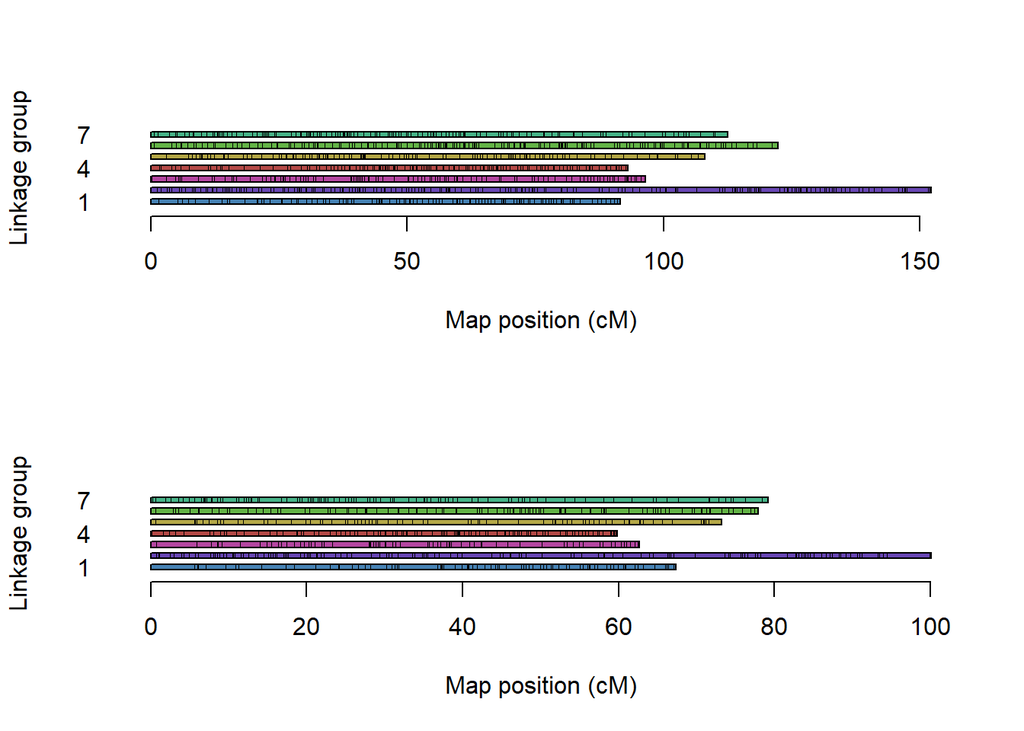

```r
parallel::clusterExport(cl, "dat")
MAPs.err <- parallel::parLapply(cl,MAPs,my.error.func)
parallel::stopCluster(cl)

par(mfrow=c(2,1))
plot_map_list(MAPs, col = "ggstyle")
plot_map_list(MAPs.err, col = "ggstyle")
```

After constructing the maps a 5% global error rate is applied to the chain to allow for the chain to make small changes that correct for possible genotyping error. The difference is seen the the picture above where the second map is shorter indicating a better map.

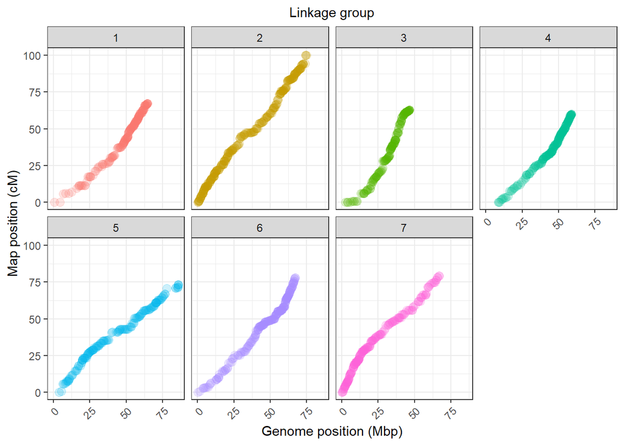

```r
plot_genome_vs_map(MAPs.err, same.ch.lg = T)
```

```r
summary_maps(MAPs.err)
```

```
##
## Your dataset contains removed (redundant) markers. Once finished the maps, remember to add them back with the function 'update_map'.
```

```
##      LG Genomic sequence Map length (cM) Markers/cM Simplex Double-simplex Multiplex Total Max gap
## 1     1                1           67.37       2.29      44             28        82   154    5.62
## 2     2                2           100.1       2.63      68             54       141   263    5.48
## 3     3                3            62.7       2.36      50             29        69   148    5.19
## 4     4                4           59.87       2.97      58             30        90   178    3.39
## 5     5                5           73.22       1.97      63             12        69   144    5.18
## 6     6                6           77.95       2.63      79             50        76   205    3.13
## 7     7                7            79.2       2.36      53             69        65   187    3.92
## 8 Total             <NA>          520.41       2.46     415            272       592  1279    4.56
```

# Genotypic probabilites for use in QTL mapping

Genotypic probabilites will be used in QTL mapping thus we need to save this for use in next session

```r
genoprob.err <- vector("list", 7)
for(i in 1:7)
   genoprob.err[[i]] <- calc_genoprob_error(input.map = MAPs.err[[i]], error = 0.05)
```

```
## Ploidy level:4
## Number of individuals:161
##  ..................................................
##  ..................................................
##  ..................................................
##  ...........
## Ploidy level:4
## Number of individuals:161
##  ..................................................
##  ..................................................
##  ..................................................
##  ...........
## Ploidy level:4
## Number of individuals:161
##  ..................................................
##  ..................................................
##  ..................................................
##  ...........
## Ploidy level:4
## Number of individuals:161
##  ..................................................
##  ..................................................
##  ..................................................
##  ...........
## Ploidy level:4
## Number of individuals:161
##  ..................................................
##  ..................................................
##  ..................................................
##  ...........
## Ploidy level:4
## Number of individuals:161
##  ..................................................
##  ..................................................
##  ..................................................
##  ...........
## Ploidy level:4
## Number of individuals:161
##  ..................................................
##  ..................................................
##  ..................................................
##  ...........
```

```r
saveRDS(genoprob.err, file="genoprob.err.RDS")
```

# homolog prob

```r
homolog_probs = calc_homologprob(genoprob.err)
```

```
##
## Linkage group  1 ...
## Linkage group  2 ...
## Linkage group  3 ...
## Linkage group  4 ...
## Linkage group  5 ...
## Linkage group  6 ...
## Linkage group  7 ...
```

# HMM chain changing and imputing genotypes

The HMM chain will make small changes to the progeny genotype calls (dosage) so it fits the better in the map. As you increase the global error rate, you allow the chain more freedom to make more changes. This is represented in the figure below.

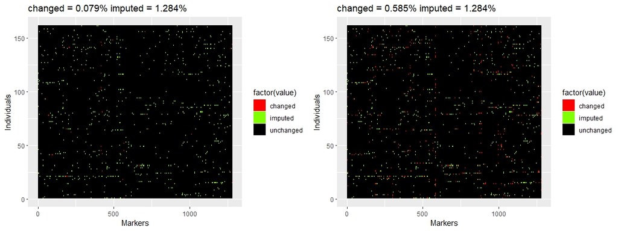

# working in polymapR

polymapR has the advantage of lower computational overhead, however less automatic and clustering may be more difficult. However if you want to work with this platform, you can use export the mappoly.data

```r
library(polymapR)
```

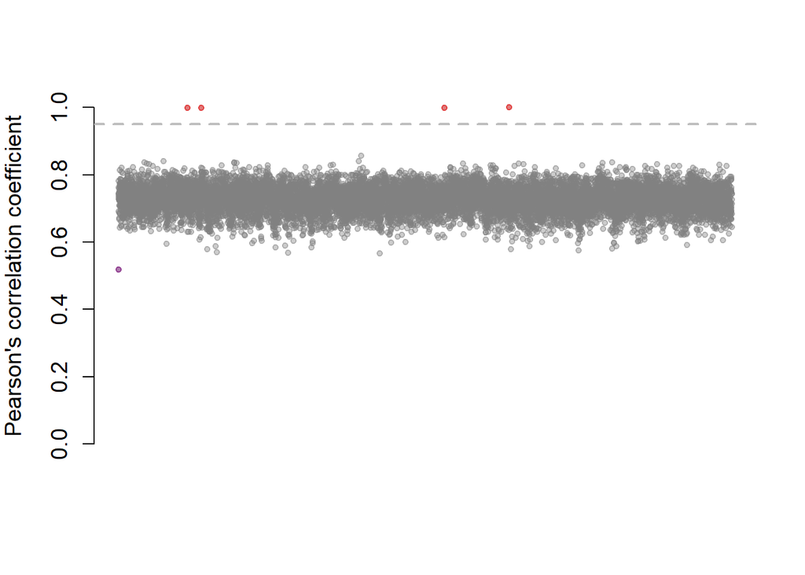

```
##
## Combining X16400_N020 & X16400_N023 into X16400_N020
##
## Combining X16035_N038 & X16400_N038 into X16035_N038
##
## Combining X16405_N112 & X16405_N113 into X16405_N112
##
## Combining X16400_N060 & X16400_N006 into X16400_N060
##
## ####  4 individuals removed:
##
##      _             _             _             _
## [1,] "X16400_N023" "X16400_N038" "X16405_N113" "X16400_N006"
## |_           |_           |_           |_           |
## |:-----------|:-----------|:-----------|:-----------|
## |X16400_N023 |X16400_N038 |X16405_N113 |X16400_N006 |
```

```r
ALL_dosages =  export_data_to_polymapR(dat)

screened_data <- screen_for_duplicate_individuals(dosage_matrix = ALL_dosages,
                                                   cutoff = 0.95,
                                                   plot_cor = T)
```

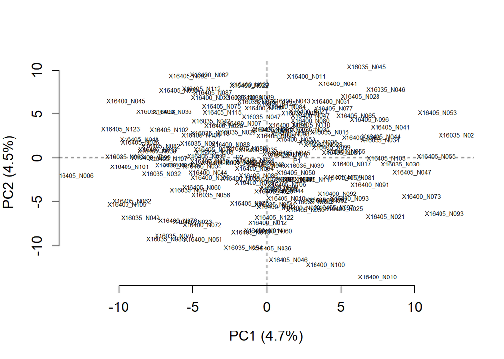

```r
PCA_progeny(screened_data)
```

# Rerun map

Okay now that we found some duplicates, lets remove them from the dataset and rerun everything from the top… it should not take that long maybe max 10 min

```r
dat = read_geno_csv(file="../data/BExMG_subset_removed_dup.csv", ploidy = 4)
```

```
## Reading the following data:
##     Ploidy level: 4
##     No. individuals:  157
##     No. markers:  1382
##     No. informative markers:  1382 (100%)
##     ...
##     Done with reading.
##     Filtering non-conforming markers.
##     ...
##     Done with filtering.
```

```r
## Filtering dataset by marker
dat = filter_missing(input.data = dat, type = "marker",
                      filter.thres = 0.05, inter = F)
## Filtering dataset by individual
dat = filter_missing(input.data = dat, type = "individual",
                      filter.thres = 0.05, inter = F)
## Filter according to segregation test
pval.bonf = 0.05/dat$n.mrk
mrks.chi.filt = filter_segregation(dat, chisq.pval.thres =  pval.bonf, inter = F)
seq.init = make_seq_mappoly(mrks.chi.filt)
## Accounting for recombination fractions
all.rf.pairwise = est_pairwise_rf(input.seq = seq.init, ncpus = 6)
```

```
## INFO: Using  6  CPUs for calculation.
## INFO: Done with 895791  pairs of markers
## INFO: Calculation took: 100.94 seconds
```

```r
mat = rf_list_to_matrix(all.rf.pairwise)
```

```
## INFO: Going singlemode. Using one CPU.
```

```r
## Getting group information (UPGMA)
grs = group_mappoly(input.mat = mat,
                     expected.groups = 7,
                     comp.mat = TRUE,
                     inter = F)
grs
```

```
##   This is an object of class 'mappoly.group'
##   ------------------------------------------
##   Criteria used to assign markers to groups:
##
##     - Number of markers:          1339
##     - Number of linkage groups:   7
##     - Number of markers per linkage groups:
##     group n.mrk
##         1   167
##         2   217
##         3   155
##         4   148
##         5   277
##         6   190
##         7   185
##   ------------------------------------------
##     1   6   3   5   2   7   4 NoChr
## 1 160   1   5   0   0   0   1     0
## 2   2 211   1   0   2   1   0     0
## 3   1   0 151   0   0   3   0     0
## 4   1   1   0 145   0   1   0     0
## 5   0   0   0   1 270   5   1     0
## 6   0   0   0   0   1 189   0     0
## 7   0   0   0   0   0   0 185     0
##   ------------------------------------------
```

```r
## Making groups with intersection between UPGMA (rf) + genomic information (discards scaffolds)

LGS.inter=vector("list", 7)
for(j in 1:7){
  temp1 = make_seq_mappoly(grs, j, genomic.info=1)
  tpt = make_pairs_mappoly(all.rf.pairwise, input.seq = temp1)
  temp2 = rf_snp_filter(input.twopt = tpt, diagnostic.plot = FALSE)
  tpt2 = make_pairs_mappoly(tpt, input.seq = temp2)
  LGS.inter[[as.numeric(names(table(temp2$chrom))[which.max(table(temp2$chrom))])]] = list(seq = temp2, tpt = tpt2)
}


## Making groups only with genomic information (tends to bring more markers, but also discards scaffolds)
LGS.genomic = vector("list", 7)
for (i in 1:7){
  tempseq1 = make_seq_mappoly(dat, arg = paste0("seq",i), genomic.info = 1)
  mrks = intersect(tempseq1$seq.mrk.names, seq.init$seq.mrk.names)
  tempseq = make_seq_mappoly(dat, arg = mrks)
  temptpt = make_pairs_mappoly(all.rf.pairwise, input.seq = tempseq)
  rffilt = rf_snp_filter(input.twopt = temptpt, diagnostic.plot = FALSE)
  temptpt2 = make_pairs_mappoly(temptpt, input.seq = rffilt)
  LGS.genomic[[as.numeric(unique(rffilt$chrom))]] = list(seq = rffilt, tpt = temptpt2)
}


## Making groups with UPGMA (rf) information (includes scaffolds)
LGS.upgma=vector("list", 7)
for(j in 1:7){
  temp1 = make_seq_mappoly(grs, j)
  tpt = make_pairs_mappoly(all.rf.pairwise, input.seq = temp1)
  temp2 = rf_snp_filter(input.twopt = tpt, diagnostic.plot = FALSE)
  tpt2 = make_pairs_mappoly(tpt, input.seq = temp2)
  LGS.upgma[[as.numeric(names(table(temp2$chrom))[which.max(table(temp2$chrom))])]] = list(seq = temp2, tpt = tpt2)
}


## Comparing number of markers in each group
comp = data.frame(UPGMA_Genomic = unlist(lapply(LGS.inter, function(x) length(x$seq$seq.num))),
                  Genomic = unlist(lapply(LGS.genomic, function(x) length(x$seq$seq.num))),
                  UPGMA = unlist(lapply(LGS.upgma, function(x) length(x$seq$seq.num))))
comp
```

```
##   UPGMA_Genomic Genomic UPGMA
## 1           152     155   158
## 2           257     261   265
## 3           143     149   149
## 4           175     177   175
## 5           138     139   140
## 6           200     202   208
## 7           181     189   181
```

```r
LGS<-LGS.upgma

## Performing parallel computation of hidden markov
phasing_and_hmm_rf <- function(X){
  fl <- paste0("output_map_ch_", unique(X$seq$chrom), ".txt")
  sink(fl)
  map <- est_rf_hmm_sequential(input.seq = X$seq,
                               start.set = 3,
                               thres.twopt = 10,
                               thres.hmm = 50,
                               extend.tail = 30,
                               twopt = X$tpt,
                               verbose = TRUE,
                               phase.number.limit = 20,
                               sub.map.size.diff.limit = 5)
  sink()
  return(map)
}


# 5% genotyping error
my.error.func<-function(X){
  x<-est_full_hmm_with_global_error(input.map = X,
                                    error = 0.05,
                                    tol = 10e-4,
                                    verbose = FALSE)
  return(x)
}
#upgma
#hidden markov based off physical location
cl <- parallel::makeCluster(7)
parallel::clusterEvalQ(cl, require(mappoly))
```

```
## [[1]]
## [1] TRUE
##
## [[2]]
## [1] TRUE
##
## [[3]]
## [1] TRUE
##
## [[4]]
## [1] TRUE
##
## [[5]]
## [1] TRUE
##
## [[6]]
## [1] TRUE
##
## [[7]]
## [1] TRUE
```

```r
parallel::clusterExport(cl, "dat")
MAPs_nodup <- parallel::parLapply(cl,LGS, phasing_and_hmm_rf)
parallel::stopCluster(cl)

# account for error
cl <- parallel::makeCluster(7)
parallel::clusterEvalQ(cl, require(mappoly))
```

```
## [[1]]
## [1] TRUE
##
## [[2]]
## [1] TRUE
##
## [[3]]
## [1] TRUE
##
## [[4]]
## [1] TRUE
##
## [[5]]
## [1] TRUE
##
## [[6]]
## [1] TRUE
##
## [[7]]
## [1] TRUE
```

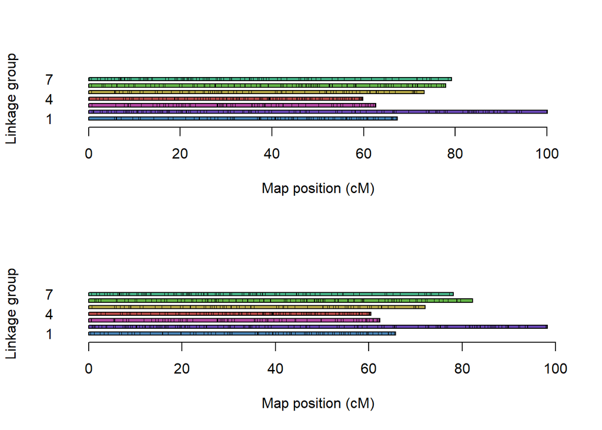

```r
parallel::clusterExport(cl, "dat")
MAPs_nodup.err <- parallel::parLapply(cl,MAPs_nodup,my.error.func)
parallel::stopCluster(cl)

par(mfrow=c(2,1))
plot_map_list(MAPs.err, col = "ggstyle")
plot_map_list(MAPs_nodup.err, col = "ggstyle")
```

```r
summary_maps(MAPs.err)
```

```
##
## Your dataset contains removed (redundant) markers. Once finished the maps, remember to add them back with the function 'update_map'.
```

[output not shown]

```r
summary_maps(MAPs_nodup.err)
```

```
##
## Your dataset contains removed (redundant) markers. Once finished the maps, remember to add them back with the function 'update_map'.
```

```
##      LG Genomic sequence Map length (cM) Markers/cM Simplex Double-simplex Multiplex Total Max gap
## 1     1                1           65.75       2.39      47             29        81   157     4.9
## 2     2                2           98.26       2.68      70             52       141   263    4.64
## 3     3                3           62.38       2.39      47             28        74   149    5.19
## 4     4                4            60.5       2.86      57             30        86   173    3.15
## 5     5                5           72.09       1.93      62             11        66   139    4.76
## 6     6                6           82.27        2.5      77             52        77   206    3.29
## 7     7                7           78.14       2.32      53             68        60   181     3.9
## 8 Total             <NA>          519.39       2.44     413            270       585  1268    4.26
```

```r
genoprob.err <- vector("list", 7)
for(i in 1:7)
   genoprob.err[[i]] <- calc_genoprob_error(input.map = MAPs_nodup.err[[i]], error = 0.05)
```

```
## Ploidy level:4
## Number of individuals:156
##  ..................................................
##  ..................................................
##  ..................................................
##  ......
## Ploidy level:4
## Number of individuals:156
##  ..................................................
##  ..................................................
##  ..................................................
##  ......
## Ploidy level:4
## Number of individuals:156
##  ..................................................
##  ..................................................
##  ..................................................
##  ......
## Ploidy level:4
## Number of individuals:156
##  ..................................................
##  ..................................................
##  ..................................................
##  ......
## Ploidy level:4
## Number of individuals:156
##  ..................................................
##  ..................................................
##  ..................................................
##  ......
## Ploidy level:4
## Number of individuals:156
##  ..................................................
##  ..................................................
##  ..................................................
##  ......
## Ploidy level:4
## Number of individuals:156
##  ..................................................
##  ..................................................
##  ..................................................
##  ......
```

```r
saveRDS(genoprob.err, file="genoprob.err.nodup.RDS")
```